# HW6_JeffUyekawa_TorchBasics

Instruction: This homework is not finalized. I will fill out this assignment with more code chunk. If you don't need additional code to help you finish the homework, you can work on it with yout own code now.

1. Construct a linear network to learn the prameter $w$ in the following code. You will see that $w$ here is the same as the class example, but the convergence speed is different.

```python
import torch
import torch.nn as nn
# #Single variable regression by torch
#y=2*x
x=torch.tensor([[0.1],[0.2],[0.3],[0.4]], dtype=torch.float32)
y=torch.tensor([[0.2],[0.4],[0.6],[0.8]], dtype=torch.float32)
#w=torch.tensor(0.0, dtype=torch.float32,requires_grad=True)

n_sample, n_feature = x.shape

input_size = 1
output_size = 1

#Using classes to define nn

class LinearRegression(torch.nn.Module):
    def __init__(self,input_dim,output_dim):
        super().__init__()
        #Define the Layers
        self.lin= nn.Linear(input_dim,output_dim)

    def forward(self,x: torch.Tensor):
        return self.lin(x)



model = LinearRegression(input_size,output_size)

#learning rate
lr=0.1

n_iter = 1000
#Loss Function
loss_nn = torch.nn.MSELoss() #Mean Square Error
optimizer = torch.optim.SGD(model.parameters(),lr=0.8) #Stochastic Gradient Descent



for epoch in range(n_iter):

    #forward pass
    y_pred =model(x)

    #loss function
    l=loss_nn(y_pred,y)

    optimizer.zero_grad()
    #Compute gradients

    l.backward() #sets loss funciton as the function which we are computing partials for

    #Update w
    optimizer.step() #Take 1 step of gradient descent

    [w,b]=model.parameters()
    if epoch % 100 == 0:
        print(f'epoch {epoch}: w={w.item():.3f}, b={b.item():.3f}  loss ={l:.3f}')


  #This keeps the gradients from accumulating with each iteration.
```

```
epoch 0: w=-0.409, b=1.346  loss =1.190
epoch 100: w=1.613, b=0.098  loss =0.002
epoch 200: w=1.942, b=0.015  loss =0.000
epoch 300: w=1.991, b=0.002  loss =0.000
epoch 400: w=1.999, b=0.000  loss =0.000
epoch 500: w=2.000, b=0.000  loss =0.000
epoch 600: w=2.000, b=0.000  loss =0.000
epoch 700: w=2.000, b=0.000  loss =0.000
epoch 800: w=2.000, b=0.000  loss =0.000
epoch 900: w=2.000, b=0.000  loss =0.000
```

1. Verify the Approximation Theorem II we proved in class. Construct a neural network in the theorem to approximate $x^2$ on $[-1,1]$. Let $\epsilon = 0.1$, build your training set wisely so the error is bounded by $\epsilon$.

```
epoch 0: w=2.000,  loss =0.388
epoch 100: w=2.000,  loss =0.038
epoch 200: w=2.000,  loss =0.019
epoch 300: w=2.000,  loss =0.010
epoch 400: w=2.000,  loss =0.005
epoch 500: w=2.000,  loss =0.003
epoch 600: w=2.000,  loss =0.002
epoch 700: w=2.000,  loss =0.001
epoch 800: w=2.000,  loss =0.001
epoch 900: w=2.000,  loss =0.001
```

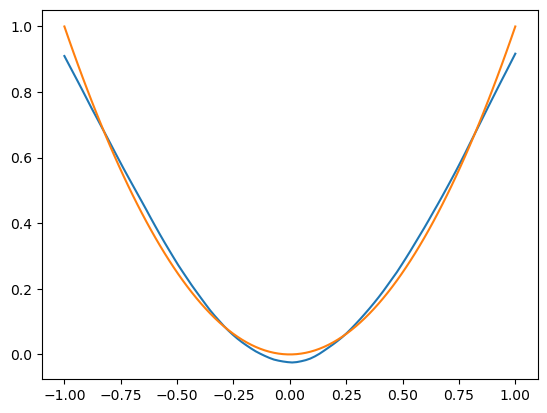

```python
import numpy as np
import matplotlib.pyplot as plt

epsilon = 0.1
a = -1
b= 1

x= torch.tensor(np.linspace(a,b,100).reshape(100,1),dtype=torch.float32)
y = x**2

n_sample, n_feature = x.shape

input_size = 1
output_size = 1

#Using classes to define nn

class LinearRegression(torch.nn.Module):
    def __init__(self):
        super().__init__()
        #Define the Layers
        self.Linear = nn.Sequential(

        nn.Linear(1, 1000),
        nn.ReLU(),
        nn.Linear(1000,1),

        )

    def forward(self,x: torch.Tensor):
        y=self.Linear(x)
        return y

model = LinearRegression()

#learning rate
lr=0.001

n_iter = 1000
#Loss Function
loss_nn = torch.nn.MSELoss() #Mean Square Error
optimizer = torch.optim.SGD(model.parameters(),lr=lr) #Stochastic Gradient Descent

y1=[]


for epoch in range(n_iter):
    #forward pass
    y_pred =model(x)

    #loss function
    l=loss_nn(y_pred,y)

    optimizer.zero_grad()
    #Compute gradients
    l.backward() #sets loss funciton as the function which we are computing partials for

    #Update w
    optimizer.step() #Take 1 step of gradient descent

    #[w,b]=model.parameters()
    if epoch % 100 == 0:
        print(f'epoch {epoch}: w={w.item():.3f},  loss ={l:.3f}')
  #This keeps the gradients from accumulating with each iteration.

plt.plot(x,y_pred.detach().numpy())
plt.plot(x,x**2)
```

```python
error = max(abs((y_pred.detach()- x**2)))

print(f'Our error is {error.item():.3f}, which we compare with our epsilon = 0.1')
print('Note that our error is less than epsilon')
```

```
Our error is 0.090, which we compare with our epsilon = 0.1
Note that our error is less than epsilon
```

1. Learn the house price of Boston with a deep (at least two hidden layer) neural network.

Leave 25% of data as test data.

Use MSELoss for your loss function.

Construct a neural network with 40 nodes in the first layer, 20 nodes in the second layer, 10 nodes in the third layer, one node in output layer. Use Relu as the activation function of each layer.

Use sklearn.metrics.r2_score to evaluate the training accuracy and test accuracy. https://scikit-learn.org/stable/modules/generated/sklearn.metrics.r2_score.html

```python
from sklearn.datasets import load_boston
from sklearn.model_selection import train_test_split
import sklearn
import warnings
warnings.filterwarnings("ignore")
import pandas as pd
dataset = load_boston()
df=pd.DataFrame(dataset.data)
df.columns=dataset.feature_names
df["Price"]=dataset.target
#house price is in the last column, there might be a warning message

#Set our target as the housing prices
Y = df["Price"]
#Make our features by dropping our target column
X = df.drop(['Price'],axis = 1)

#Reshape appropriately as torch tensors
Y = torch.Tensor(Y).reshape(-1,1)
X = torch.Tensor(X.values)

#Split data
X_train, X_test, Y_train, Y_test = train_test_split(X,Y,test_size= 0.25)

#Scale data
x_scaler = sklearn.preprocessing.StandardScaler()
X_train = x_scaler.fit_transform(X_train)
X_test = x_scaler.transform(X_test)

#I think the scaling switched our data back to a numpy array. Switch back to tensor (oops)
X_train =torch.from_numpy(X_train.astype(np.float32))
X_test = torch.from_numpy(X_test.astype(np.float32))

#Construct our Network
n_features = X_train.shape[1]
class LinearRegression(nn.Module):
    def __init__(self, n_features):
        super(LinearRegression,self).__init__()
        #Define the Layers
        self.network=nn.Sequential(
        nn.Linear(n_features,40),
        nn.ReLU(),
        nn.Linear(40,20),
        nn.ReLU(),
        nn.Linear(20,10),
        nn.ReLU(),
        nn.Linear(10,1),
        nn.ReLU()
        )

    def forward(self,x):
        y=self.network(x)
        return y
```

```python
 #Define Model, Loss Function and Optimizer

model = LinearRegression(n_features)

loss_fn = nn.MSELoss()

optimizer = torch.optim.SGD(model.parameters(),lr =0.001)
```

```python
#Training Loop

num_iters = 2000

for epoch in range(num_iters):
    #forward pass
    Y_pred = model(X_train)
    loss = loss_fn(Y_pred,Y_train)

    #Backward & Parameter Update
    loss.backward()
    optimizer.step()
    optimizer.zero_grad()

    if epoch % 100 == 0:
        print(f'Epoch: {epoch}, Loss: {loss.item():.3f}')
```

```
Epoch: 0, Loss: 554.203
Epoch: 100, Loss: 14.212
Epoch: 200, Loss: 11.454
Epoch: 300, Loss: 10.289
Epoch: 400, Loss: 9.436
Epoch: 500, Loss: 8.768
Epoch: 600, Loss: 8.166
Epoch: 700, Loss: 7.696
Epoch: 800, Loss: 7.315
Epoch: 900, Loss: 7.012
Epoch: 1000, Loss: 6.730
Epoch: 1100, Loss: 6.486
Epoch: 1200, Loss: 6.272
Epoch: 1300, Loss: 6.069
Epoch: 1400, Loss: 5.884
Epoch: 1500, Loss: 5.714
Epoch: 1600, Loss: 5.556
Epoch: 1700, Loss: 5.402
Epoch: 1800, Loss: 5.249
Epoch: 1900, Loss: 5.091
```

```python
#Evaluate on training set first to check for underfitting
print(sklearn.metrics.r2_score(Y_pred.detach().numpy(),Y_train))
```

```
0.9324195574147383
```

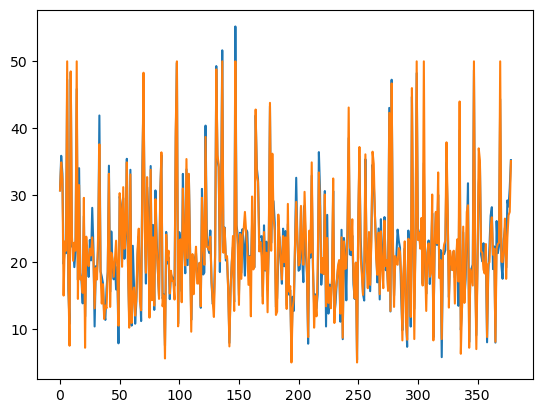

```python
#Visualize predictions vs training targets
import matplotlib.pyplot as plt
plt.plot(Y_pred.detach().numpy())
plt.plot(Y_train.detach().numpy())
```

```python
#Evalute Model on test set
Y_pred = model(X_test)

r2 = sklearn.metrics.r2_score(Y_pred.detach().numpy(),Y_test)

print(f'R2 score on test set is {r2}')
```

```
R2 score on test set is 0.8553540513567679
```

It appears that our model is slightly overfit. From a quick bit of research, we could try fixing this by adding some form of regularization term, or simplifiying the model. Maybe use less iterations in our training loop, or possible use less feautures or less nodes/layers to balance out. Overall, though, an R2 score of 0.855 on our test set is pretty good.